# Survivor Analysis

Group 1

6/08/2020

### Step 1: Read in and visualize the data

#### Summary statistics

Data Frame Summary

lung

**N**: 228

| **Variable** | **Stats / Values** | **Freqs (% of Valid)** | **Graph** | **Missing** |
| --- | --- | --- | --- | --- |
| inst [numeric] | mean (sd) : 11.09 (8.3) min < med < max : 1 < 11 < 33 IQR (CV) : 13 (0.75) | 18 distinct values |  | 1 (0.44%) |
| time [numeric] | mean (sd) : 305.23 (210.65) min < med < max : 5 < 255.5 < 1022 IQR (CV) : 229.75 (0.69) | 186 distinct values |  | 0 (0%) |
| status [numeric] | mean (sd) : 1.72 (0.45) min < med < max : 1 < 2 < 2 IQR (CV) : 1 (0.26) | 1 : 63 (27.6%) 2 : 165 (72.4%) |  | 0 (0%) |
| age [numeric] | mean (sd) : 62.45 (9.07) min < med < max : 39 < 63 < 82 IQR (CV) : 13 (0.15) | 42 distinct values |  | 0 (0%) |
| sex [numeric] | mean (sd) : 1.39 (0.49) min < med < max : 1 < 1 < 2 IQR (CV) : 1 (0.35) | 1 : 138 (60.5%) 2 : 90 (39.5%) |  | 0 (0%) |
| ph.ecog [numeric] | mean (sd) : 0.95 (0.72) min < med < max : 0 < 1 < 3 IQR (CV) : 1 (0.75) | 0 : 63 (27.8%) 1 : 113 (49.8%) 2 : 50 (22.0%) 3 : 1 (0.4%) |  | 1 (0.44%) |
| ph.karno [numeric] | mean (sd) : 81.94 (12.33) min < med < max : 50 < 80 < 100 IQR (CV) : 15 (0.15) | 50 : 6 (2.6%) 60 : 19 (8.4%) 70 : 32 (14.1%) 80 : 67 (29.5%) 90 : 74 (32.6%) 100 : 29 (12.8%) |  | 1 (0.44%) |
| pat.karno [numeric] | mean (sd) : 79.96 (14.62) min < med < max : 30 < 80 < 100 IQR (CV) : 20 (0.18) | 30 : 2 (0.9%) 40 : 2 (0.9%) 50 : 4 (1.8%) 60 : 30 (13.3%) 70 : 41 (18.2%) 80 : 51 (22.7%) 90 : 60 (26.7%) 100 : 35 (15.6%) |  | 3 (1.32%) |
| meal.cal [numeric] | mean (sd) : 928.78 (402.17) min < med < max : 96 < 975 < 2600 IQR (CV) : 515 (0.43) | 60 distinct values |  | 47 (20.61%) |
| wt.loss [numeric] | mean (sd) : 9.83 (13.14) min < med < max : -24 < 7 < 68 IQR (CV) : 15.75 (1.34) | 53 distinct values |  | 14 (6.14%) |

Generated by summarytools 0.8.7 ([R](https://www.r-project.org/) version 3.5.1)  
2020-06-08

#### Data structure

| inst | time | status | age | sex | ph.ecog | ph.karno | pat.karno | meal.cal | wt.loss |
| --- | --- | --- | --- | --- | --- | --- | --- | --- | --- |
| 3 | 306 | 2 | 74 | 1 | 1 | 90 | 100 | 1175 | NA |
| 3 | 455 | 2 | 68 | 1 | 0 | 90 | 90 | 1225 | 15 |
| 3 | 1010 | 1 | 56 | 1 | 0 | 90 | 90 | NA | 15 |
| 5 | 210 | 2 | 57 | 1 | 1 | 90 | 60 | 1150 | 11 |
| 1 | 883 | 2 | 60 | 1 | 0 | 100 | 90 | NA | 0 |

### Step 2: Missing value imputation

#### Overview

- As shown in the summary above, there is relatively little missing information in our data, with the exception of meal calories and wt.loss. We explored these values and imputed them.

#### Missing Data

|  | time | status | age | sex | inst | ph.ecog | ph.karno | pat.karno | wt.loss | meal.cal |  |
| --- | --- | --- | --- | --- | --- | --- | --- | --- | --- | --- | --- |
| 167 | 1 | 1 | 1 | 1 | 1 | 1 | 1 | 1 | 1 | 1 | 0 |
| 42 | 1 | 1 | 1 | 1 | 1 | 1 | 1 | 1 | 1 | 0 | 1 |
| 10 | 1 | 1 | 1 | 1 | 1 | 1 | 1 | 1 | 0 | 1 | 1 |
| 3 | 1 | 1 | 1 | 1 | 1 | 1 | 1 | 1 | 0 | 0 | 2 |
| 2 | 1 | 1 | 1 | 1 | 1 | 1 | 1 | 0 | 1 | 1 | 1 |
| 1 | 1 | 1 | 1 | 1 | 1 | 1 | 1 | 0 | 1 | 0 | 2 |
| 1 | 1 | 1 | 1 | 1 | 1 | 1 | 0 | 1 | 0 | 0 | 3 |
| 1 | 1 | 1 | 1 | 1 | 1 | 0 | 1 | 1 | 1 | 1 | 1 |
| 1 | 1 | 1 | 1 | 1 | 0 | 1 | 1 | 1 | 1 | 1 | 1 |
|  | 0 | 0 | 0 | 0 | 1 | 1 | 1 | 3 | 14 | 47 | 67 |

#### Missing Data - Graphically

- We can look at this graphically to see which variables have many missing values.

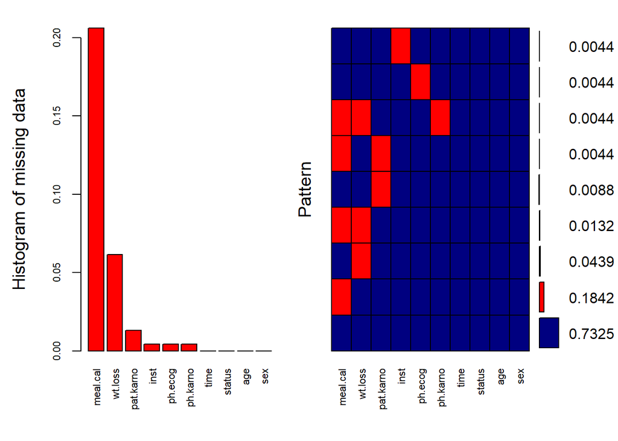

```
##
##  Variables sorted by number of missings:
##   Variable       Count
##   meal.cal 0.206140351
##    wt.loss 0.061403509
##  pat.karno 0.013157895
##       inst 0.004385965
##    ph.ecog 0.004385965
##   ph.karno 0.004385965
##       time 0.000000000
##     status 0.000000000
##        age 0.000000000
##        sex 0.000000000
```

#### Missing Data - Correction

- To correct these missing values, we will use the mice() function to perform Multivariate Imputation By Chained Equations.
- Methodological notes:
  - We will create 5 different numbers for each missing value, done in 50 different iterations.
  - Our method is predictive mean matching, the standard for the mice package, that will try and predict a number based on the information that is known.
  - Those 50 iterations will be averaged for one final number.
  - We will set a seed at 500 to keep our random results consistent.

|  | 1 | 2 | 3 | 4 | 5 |
| --- | --- | --- | --- | --- | --- |
| 3 | 975 | 1025 | 1225 | 1075 | 1225 |
| 5 | 1100 | 2200 | 1300 | 1025 | 975 |
| 12 | 488 | 1025 | 488 | 384 | 1025 |
| 13 | 625 | 413 | 413 | 1025 | 280 |
| 16 | 1225 | 1225 | 1025 | 1300 | 538 |

| inst | time | status | age | sex | ph.ecog | ph.karno | pat.karno | meal.cal | wt.loss |
| --- | --- | --- | --- | --- | --- | --- | --- | --- | --- |
| 3 | 306 | 2 | 74 | 1 | 1 | 90 | 100 | 1175 | 13 |
| 3 | 455 | 2 | 68 | 1 | 0 | 90 | 90 | 1225 | 15 |
| 3 | 1010 | 1 | 56 | 1 | 0 | 90 | 90 | 975 | 15 |
| 5 | 210 | 2 | 57 | 1 | 1 | 90 | 60 | 1150 | 11 |
| 1 | 883 | 2 | 60 | 1 | 0 | 100 | 90 | 1100 | 0 |
| 12 | 1022 | 1 | 74 | 1 | 1 | 50 | 80 | 513 | 0 |

### Step 3: Additional constructs

#### Overview

- In preparation for building our model, we created new constructs from the variables included in the data, namely:
  - We explored age constructions, looking at both 1.) ages above and below the mean value 2.) ages broken into decades. Decade-based age seemed to better explain our outcome variable, so we will use that moving forward.
  - We recoded our censoring variable (Status) to be a 0/1 indicator where 1 represents deceased and 0 represents censored (alive at the end of the observation window as far as we know).

#### Age brackets

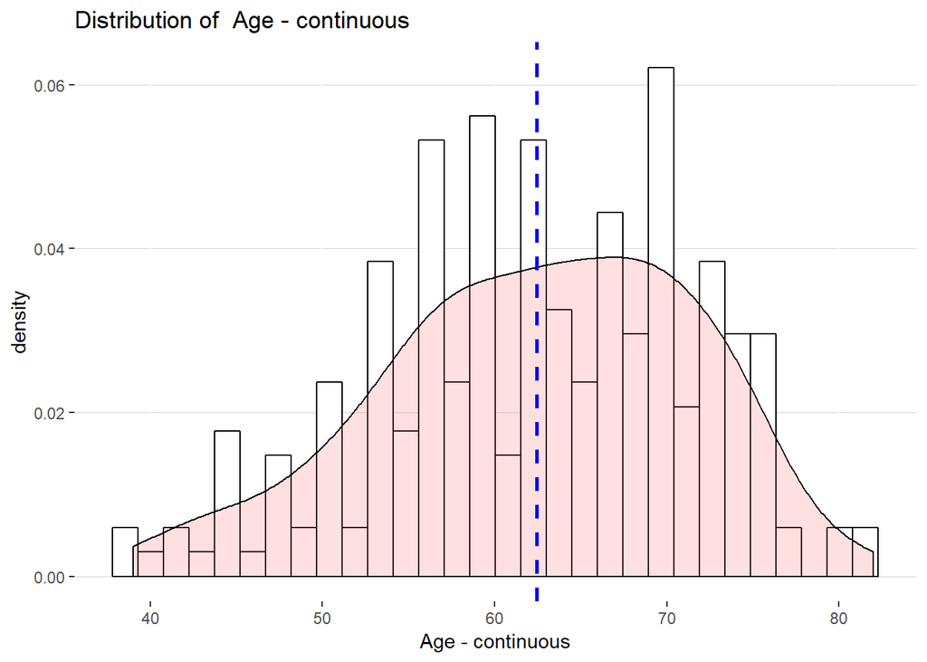

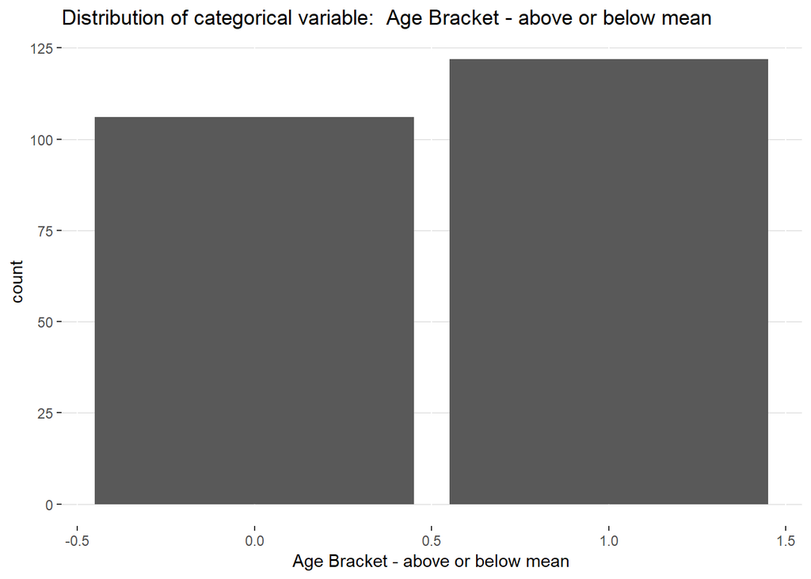

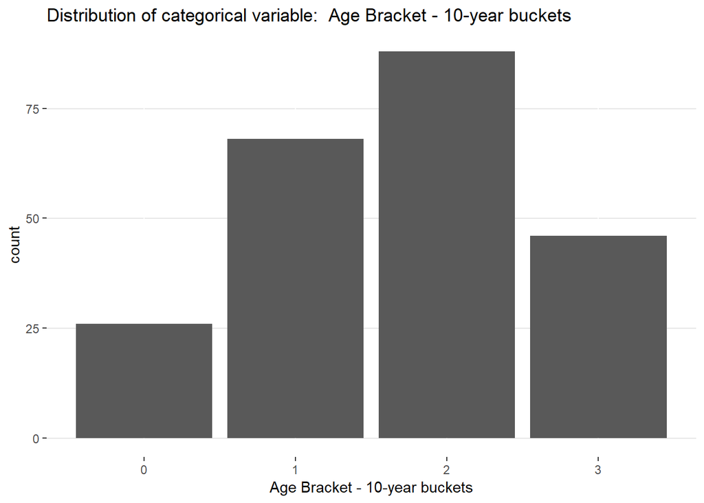

#### Censoring variable

| deceased | status | n | pct |
| --- | --- | --- | --- |
| 0 | 1 | 63 | 27.63158 |
| 1 | 2 | 165 | 72.36842 |

### Step 4: Exploratory Data Analysis

#### Overview

- Before building our model, we performed exploratory data analysis which included:
  - Assessing correlation between explanatory variables
  - Assessing variable distributions and outliers using box plots.

#### Correlations

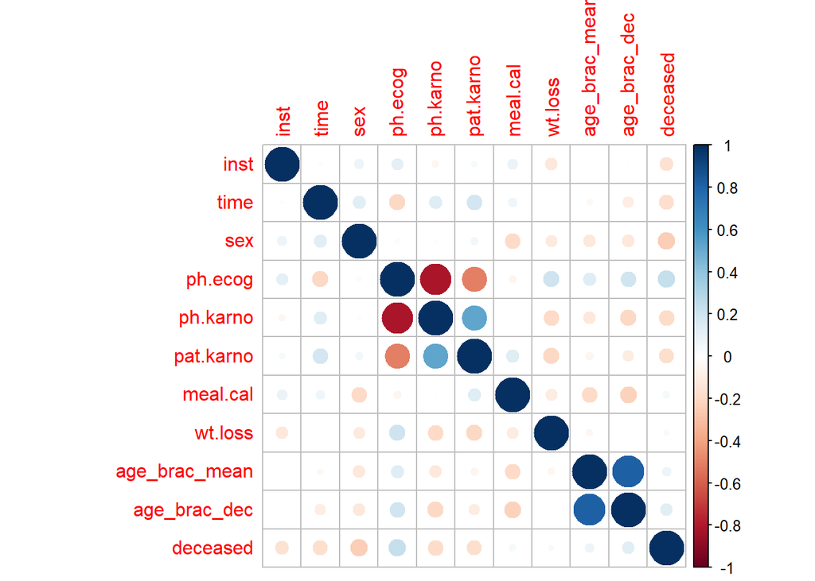

#### Box plots

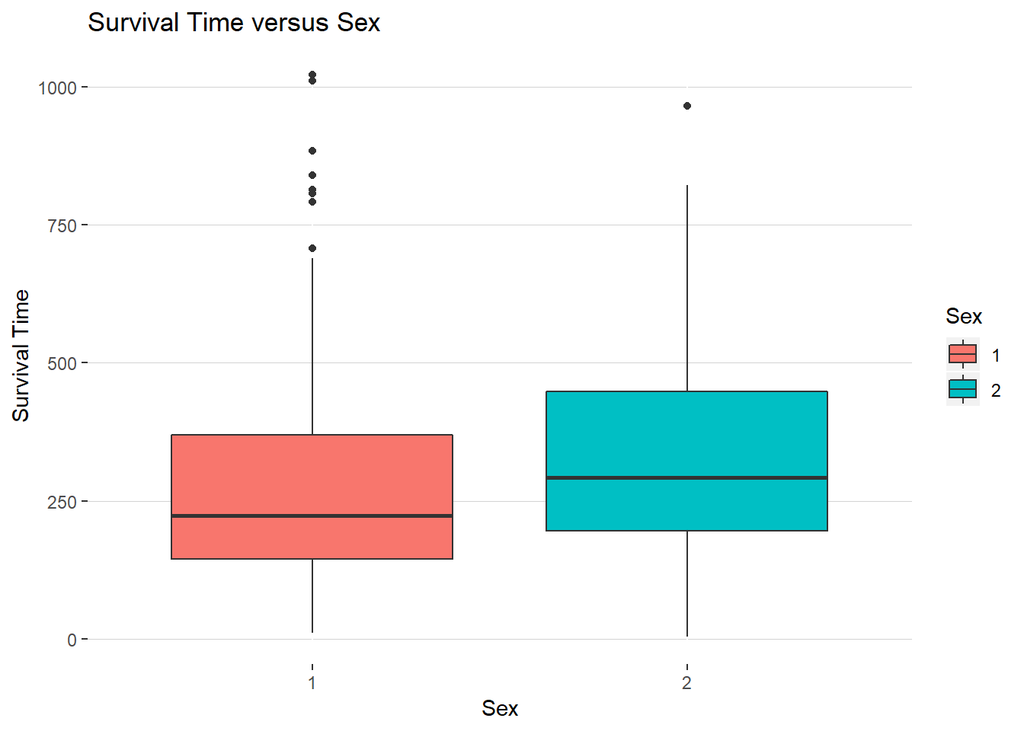

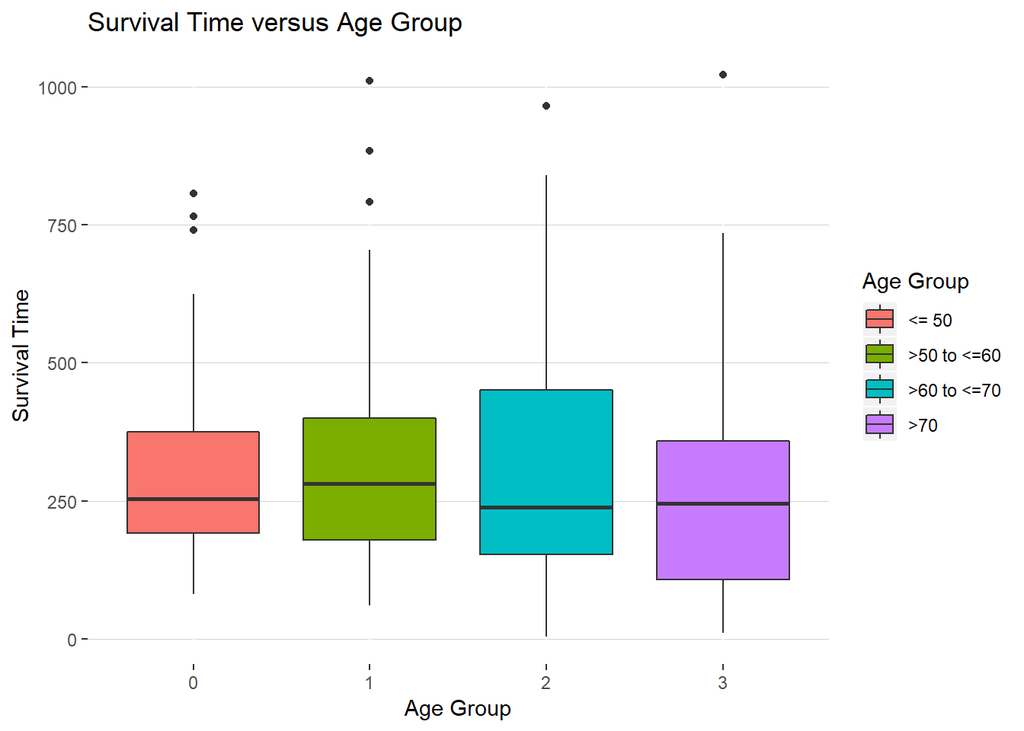

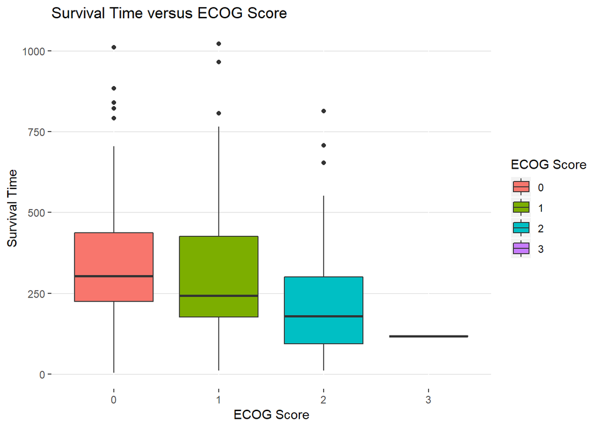

### Step 5: Examine Kaplan Meier curves

#### Overall

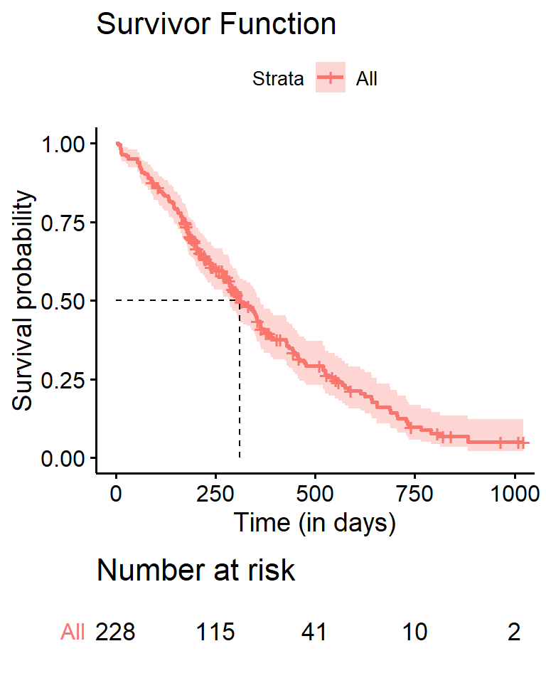

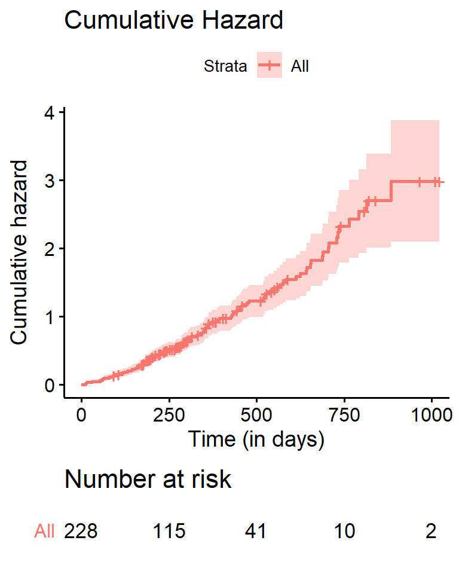

#### By Sex

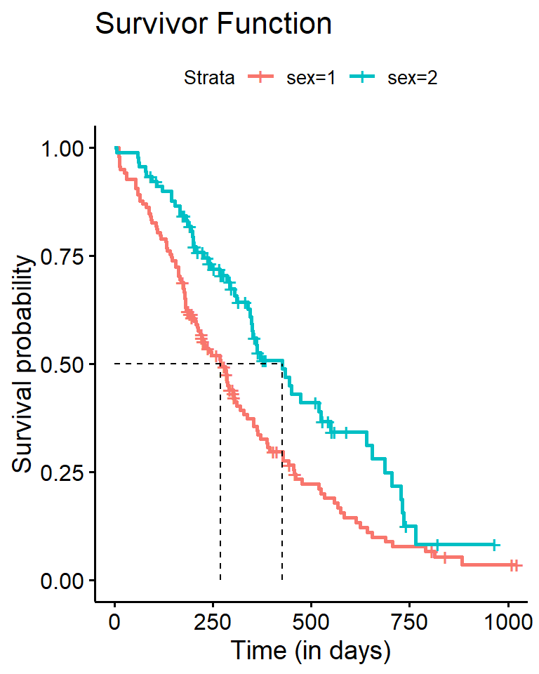

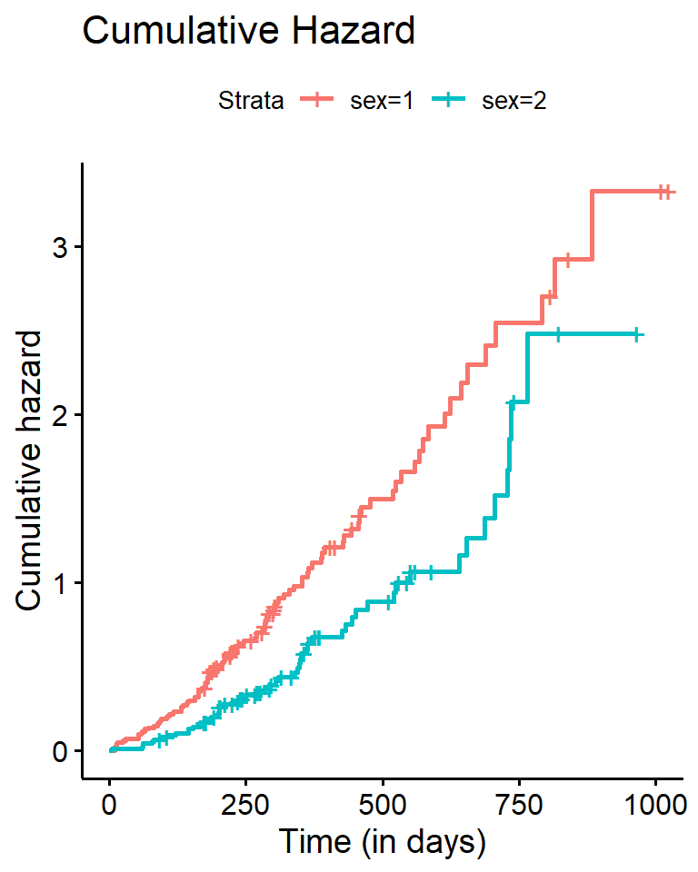

#### By Age

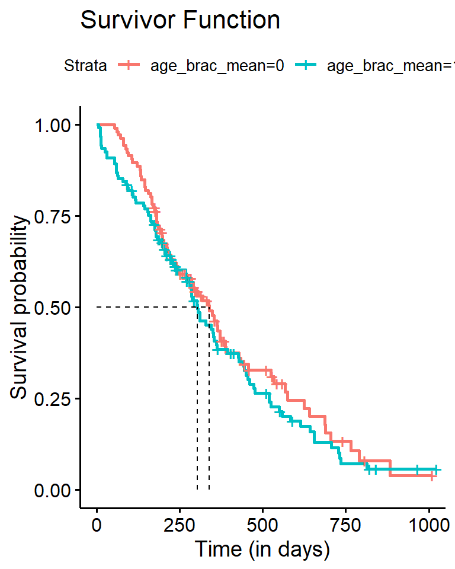

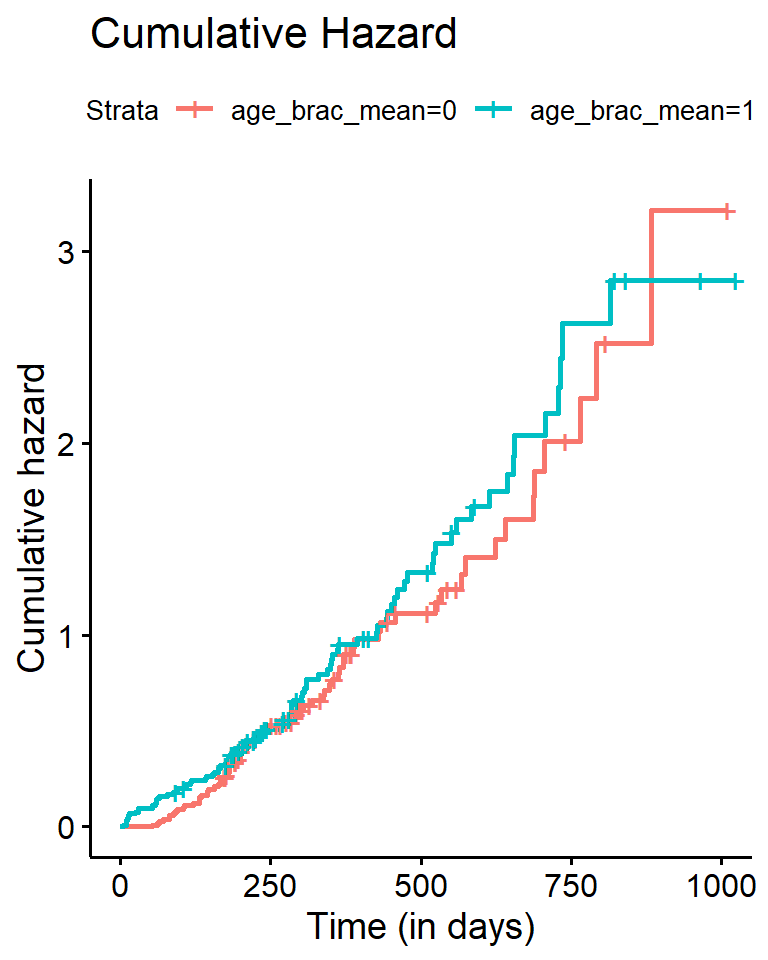

### Step 6: Estimate models

#### Sex only

```r
# Build model with one explanatory variable
cox_model1 <- coxph(formula = Surv(time, deceased) ~ sex, data = lung)

# check summary
summary(cox_model1)
```

```
## Call:
## coxph(formula = Surv(time, deceased) ~ sex, data = lung)
##
##   n= 228, number of events= 165
##
##        coef exp(coef) se(coef)      z Pr(>|z|)
## sex -0.5310    0.5880   0.1672 -3.176  0.00149 **
## ---
## Signif. codes:  0 '***' 0.001 '**' 0.01 '*' 0.05 '.' 0.1 ' ' 1
##
##     exp(coef) exp(-coef) lower .95 upper .95
## sex     0.588      1.701    0.4237     0.816
##
## Concordance= 0.579  (se = 0.022 )
## Rsquare= 0.046   (max possible= 0.999 )
## Likelihood ratio test= 10.63  on 1 df,   p=0.001
## Wald test            = 10.09  on 1 df,   p=0.001
## Score (logrank) test = 10.33  on 1 df,   p=0.001
```

```r
# visualize significant variables
# Not incredibly helpful with one explanatory var. Commented out: ggforest(cox_model1, data = lung)
```

- Interpretation:
  - Coefficients:
    - Reminder: $\lambda(t\;|\;x) = \lambda_0(t)exp(X^{T}\beta)$
    - Our coefficients represent the difference in the log hazard between males and females. For continuous variables, this represents the change in the log hazard function for a one unit change in x.
      - Example: The coefficient on sex is -0.5310. The log hazard (log instantaneous rate of death) is -0.5310 lower for females, compare to males (going from sex=1 to sex=2)
    - Exp(coef) is the hazard ratio. Exp(-coef) is therefore the (inverse) hazard ratio.
      - Example: The exp(coef) on sex is $exp(-0.5310) = 0.5880$. At a given point in time, females will have an instantaneous rate of death that is .588 times that of males.
  - Tests:
    - We have three different tests to explain the model as a whole. The first is a likelihood ratio test, which compares this model to the model with just the intercept term, based on their likelihoods.
    - Another classical approach to hypothesis testing is the Wald Test, which assesses constraints on our parameters based on the predicted estimate and its hypothesized value under the null hypothesis.
    - The log rank test compares the survival distributions for our two samples - time and status. This is used to test for our censored data.
- We can also calculate the likelihood function “by hand.”
  - A partial likelihood is the conditional probabilities of the observed individual, being chosen from the risk set to fail.
  - It can be modeled as: $\frac{\lambda(X_j|Z_j)}{\sum_{l\in R(X_j)}\lambda(X_j|Z_l)}$

```r
##################################################################
# Log partial likelihood for the Cox proportional hazards model
###################################################################
# X      : design matrix
# status : vital status (1 - dead, 0 - alive)
# times  : survival times
# n.obs  : number of observed events

# Risk set function - identify the individuals at risk at time t
risk.set <- function(t) which(times >= t)

# log partial likelihood function
log.parlik <- function(beta){
  # create a vector of T/Fs for dead or alive
  status <- as.vector(as.logical(status))
  # multiply x values by coefficients
  Xbeta  <- as.vector(X%*%beta)
  # sum the linear predictors for all individuals who have died
  lpl1   <- sum(Xbeta[status])
  temp   <- vector(   )
  for(i in 1:n.obs) temp[i] <- log(sum(exp(Xbeta[rs[[i]]])))
     lpl2 <- sum(temp)
  return(-lpl1 + lpl2)
}

# Required variables
X      <- as.matrix(cbind(lung$sex))
status <- as.vector(lung$deceased)
times  <- as.vector(lung$time)
n.obs  <- sum(lung$deceased)

# Risk set
rs <- apply(as.matrix(times[as.logical(status)]), 1, risk.set)

# Optimization step
OPT <- optim(c(5),log.parlik, control = list(maxit = 1000))

# Comparison
MAT <- cbind( cox_model1$coefficients, OPT$par)
colnames(MAT) <- c("survival package", "MPLE")
mykable(MAT, digits = 4)
```

|  | survival package | MPLE |
| --- | --- | --- |
| sex | -0.531 | -0.5312 |

#### All covariates

```r
# Build model with one explanatory variable
cox_model2 <- coxph(formula = Surv(time, deceased) ~ sex + age_brac_dec + ph.ecog +ph.karno + pat.karno + meal.cal + wt.loss, data = lung)

# check summary
summary(cox_model2)
```

```
## Call:
## coxph(formula = Surv(time, deceased) ~ sex + age_brac_dec + ph.ecog +
##     ph.karno + pat.karno + meal.cal + wt.loss, data = lung)
##
##   n= 228, number of events= 165
##
##                    coef  exp(coef)   se(coef)      z Pr(>|z|)
## sex          -0.6013413  0.5480760  0.1740096 -3.456 0.000549 ***
## age_brac_dec  0.1155638  1.1225062  0.0948246  1.219 0.222954
## ph.ecog       0.6197662  1.8584934  0.1849256  3.351 0.000804 ***
## ph.karno      0.0150148  1.0151281  0.0095294  1.576 0.115113
## pat.karno    -0.0124303  0.9876466  0.0069902 -1.778 0.075363 .
## meal.cal     -0.0000162  0.9999838  0.0002200 -0.074 0.941298
## wt.loss      -0.0115733  0.9884935  0.0066835 -1.732 0.083342 .
## ---
## Signif. codes:  0 '***' 0.001 '**' 0.01 '*' 0.05 '.' 0.1 ' ' 1
##
##              exp(coef) exp(-coef) lower .95 upper .95
## sex             0.5481     1.8246    0.3897    0.7708
## age_brac_dec    1.1225     0.8909    0.9321    1.3518
## ph.ecog         1.8585     0.5381    1.2935    2.6704
## ph.karno        1.0151     0.9851    0.9963    1.0343
## pat.karno       0.9876     1.0125    0.9742    1.0013
## meal.cal        1.0000     1.0000    0.9996    1.0004
## wt.loss         0.9885     1.0116    0.9756    1.0015
##
## Concordance= 0.652  (se = 0.026 )
## Rsquare= 0.156   (max possible= 0.999 )
## Likelihood ratio test= 38.55  on 7 df,   p=2e-06
## Wald test            = 37.74  on 7 df,   p=3e-06
## Score (logrank) test = 38.85  on 7 df,   p=2e-06
```

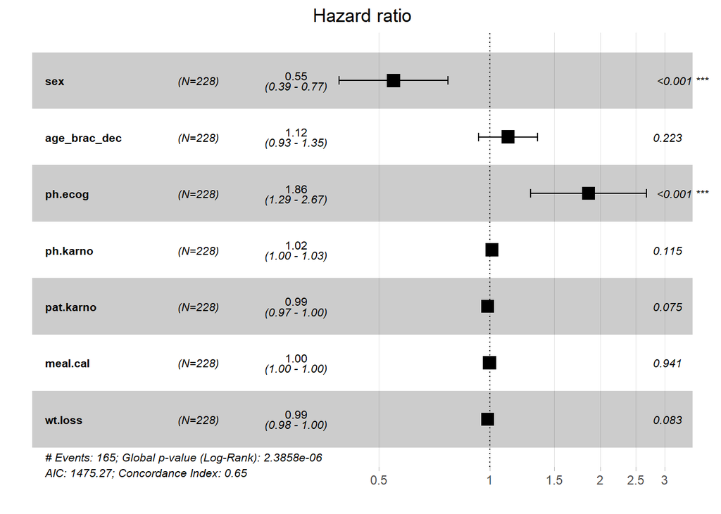

```r
# visualize significant variables
ggforest(cox_model2, data = lung)
```

- Interpretation:
  - Only two of our variables are significant - sex and ph.ecog. we can see their significance in two different ways in the summary table: the p-values (both are significant at the .01 level) and their confidence intervals on their predicted hazard ratio does not include 1.

### Step 7: Check CoxPH modeling assumptions

- After fitting out model, we check to make sure that model assumptions hold. As a reminder, some assumptions include:
  - Assumption 1: Censoring is non-informatvie.
  - Assumption 2: Survival times are independent.
  - Assumption 3: The CoxPH model assumes that the covariates do not vary with time.
  - **Assumption 4: Hazards are proportional over time. Hazard ratio is constant over time. Coefficients do not change over time.**

#### Testing the proportional hazard assumption:

##### Overall

```
##                 rho  chisq      p
## sex          0.1555  4.017 0.0451
## age_brac_dec 0.0509  0.486 0.4857
## ph.ecog      0.0873  1.287 0.2567
## ph.karno     0.2047  5.306 0.0212
## pat.karno    0.0373  0.265 0.6066
## meal.cal     0.1996  6.707 0.0096
## wt.loss      0.0361  0.262 0.6091
## GLOBAL           NA 16.860 0.0183
```

##### Sex

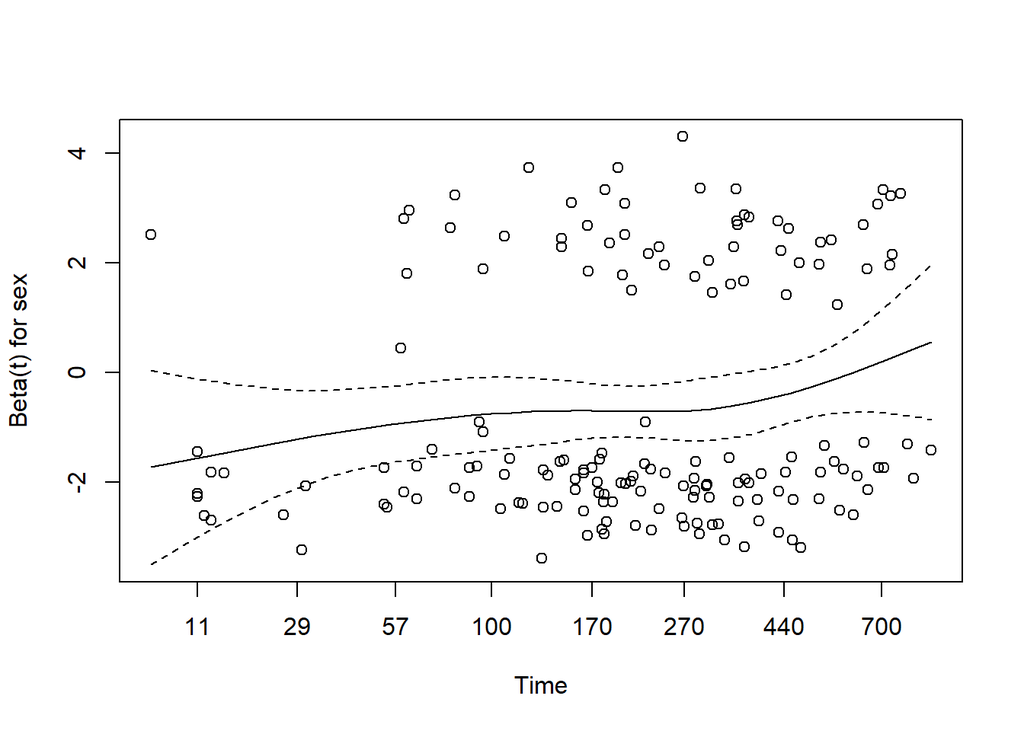

##### Age

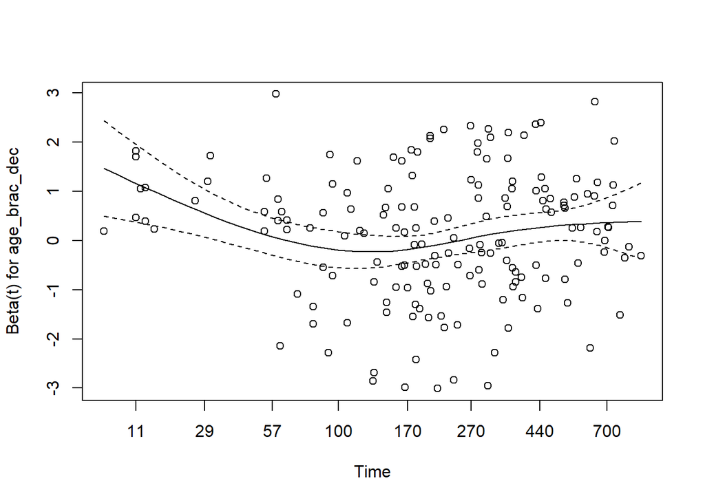

##### Ph.ecog

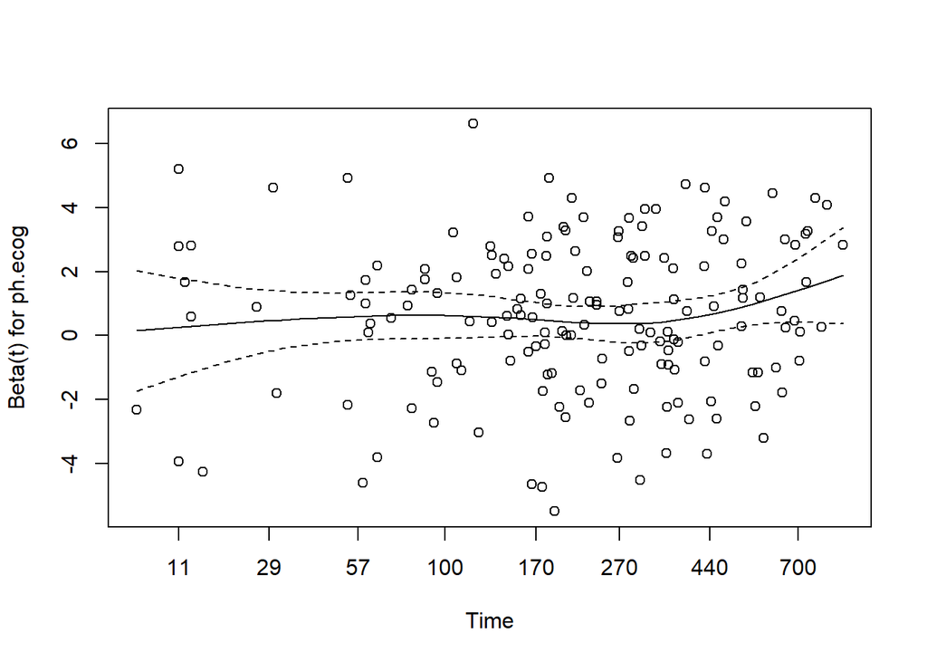

##### Ph.karno

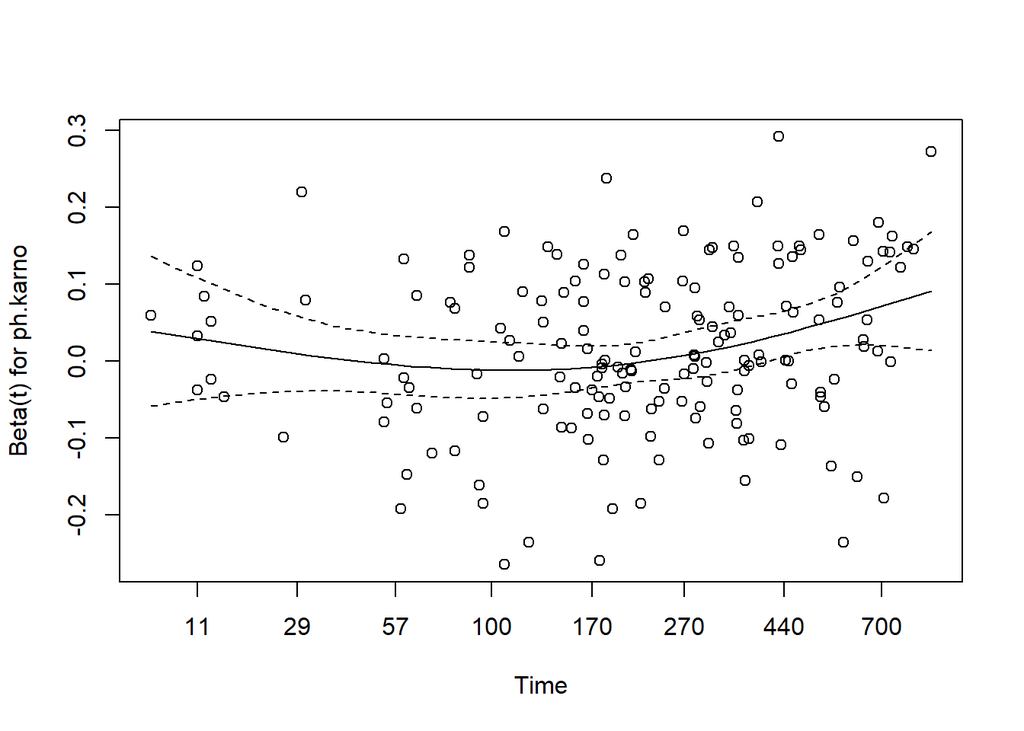

##### Pat.Karno

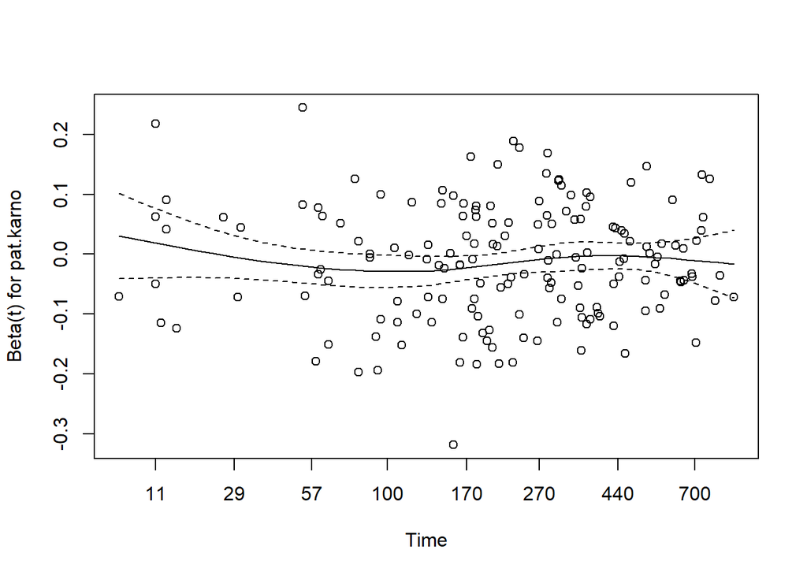

##### meal.cal

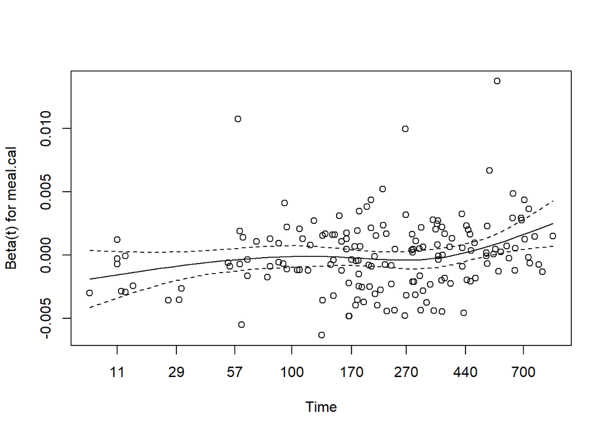

##### Wt.loss

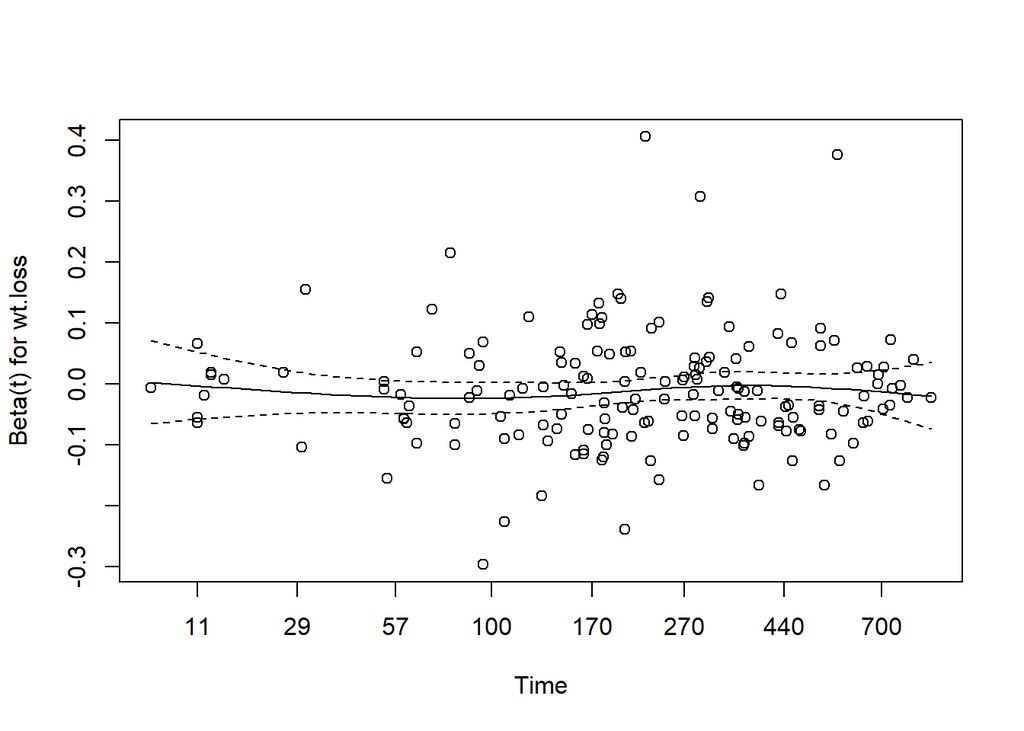

#### Corrections

- Create interaction term between time and problematic variable.
- Use the time-transform functionality in coxph() to allow for a time-dependent coefficients.
- **One of the simplest extensions is a step function for $\beta(t)$, i.e., allow for different coefficients over different time intervals.**

| inst | sex | ph.ecog | ph.karno | pat.karno | meal.cal | wt.loss | age_brac_mean | age_brac_dec | id | tstart | time | deceased | tgroup |
| --- | --- | --- | --- | --- | --- | --- | --- | --- | --- | --- | --- | --- | --- |
| 3 | 1 | 1 | 90 | 100 | 1175 | 13 | 1 | 3 | 1 | 0 | 50 | 0 | 1 |
| 3 | 1 | 1 | 90 | 100 | 1175 | 13 | 1 | 3 | 1 | 50 | 250 | 0 | 2 |
| 3 | 1 | 1 | 90 | 100 | 1175 | 13 | 1 | 3 | 1 | 250 | 306 | 1 | 3 |
| 3 | 1 | 0 | 90 | 90 | 1225 | 15 | 1 | 2 | 2 | 0 | 50 | 0 | 1 |
| 3 | 1 | 0 | 90 | 90 | 1225 | 15 | 1 | 2 | 2 | 50 | 250 | 0 | 2 |
| 3 | 1 | 0 | 90 | 90 | 1225 | 15 | 1 | 2 | 2 | 250 | 455 | 1 | 3 |

```
## Call:
## coxph(formula = Surv(tstart, time, deceased) ~ sex:strata(tgroup) +
##     age_brac_dec + ph.ecog + ph.karno:strata(tgroup) + pat.karno +
##     meal.cal + wt.loss, data = lung_new)
##
##                                      coef exp(coef)  se(coef)     z      p
## age_brac_dec                     0.115287  1.122195  0.094495  1.22 0.2225
## ph.ecog                          0.576712  1.780177  0.185725  3.11 0.0019
## pat.karno                       -0.011051  0.989009  0.006952 -1.59 0.1119
## meal.cal                        -0.000061  0.999939  0.000220 -0.28 0.7819
## wt.loss                         -0.011258  0.988805  0.006784 -1.66 0.0970
## sex:strata(tgroup)tgroup=1      -1.888188  0.151346  1.050435 -1.80 0.0723
## sex:strata(tgroup)tgroup=2      -0.705567  0.493828  0.256502 -2.75 0.0059
## sex:strata(tgroup)tgroup=3      -0.446935  0.639585  0.242861 -1.84 0.0657
## strata(tgroup)tgroup=1:ph.karno  0.032130  1.032652  0.026807  1.20 0.2307
## strata(tgroup)tgroup=2:ph.karno -0.010922  0.989138  0.011807 -0.93 0.3549
## strata(tgroup)tgroup=3:ph.karno  0.029853  1.030303  0.011489  2.60 0.0094
##
## Likelihood ratio test=52.64  on 11 df, p=2e-07
## n= 560, number of events= 165
```

```
##                                     rho    chisq      p
## age_brac_dec                    0.04706 0.409836 0.5221
## ph.ecog                         0.08310 1.134748 0.2868
## pat.karno                       0.04663 0.404014 0.5250
## meal.cal                        0.19225 6.127654 0.0133
## wt.loss                         0.04026 0.326360 0.5678
## sex:strata(tgroup)tgroup=1      0.00121 0.000247 0.9874
## sex:strata(tgroup)tgroup=2      0.04708 0.360689 0.5481
## sex:strata(tgroup)tgroup=3      0.05947 0.584613 0.4445
## strata(tgroup)tgroup=1:ph.karno 0.02103 0.077557 0.7806
## strata(tgroup)tgroup=2:ph.karno 0.06874 0.649191 0.4204
## strata(tgroup)tgroup=3:ph.karno 0.05021 0.307286 0.5794
## GLOBAL                               NA 8.316652 0.6847
```

### Step 8: Evaluate Goodness of fit

#### Analysis of Deviance

The Cox Diagnostic tests make it easy to analyze model deviance to see if the model explains more or less of the deviance than the saturated model at any points in the dataset. To interpret this chart, we can think of it this way:

- Positive values correspond to individuals that “failed too soon” compared to expected survival times
- Negative values correspond to individual that “took too long to fail” according to the model
- A high number of outliers indicate a poorly predicted by the model
1. Testing proportional Hazards assumption
- Validated when we see non-significant relationship between residuals and time
  - Look for random pattern in residual plot against time
2. Testing effect of influential observations
- We can visualize either the deviance residuals or the dfbeta values
  - Residuals should be evenly distributed about 0 with SD of 1
  - dfbeta values show changes in coefficients divided by S.E.
    - Plotting these values against beta coefficients should show random pattern with minimal outliers (influential observations)
3. Testing non-linearity
- Confirm that our continuous variables have a linear form
  - Displays graphs of continous covariates against Martingale residuals of null Cox PH models
  - Martingale Residuals (-infinity, +1)
    - Value of martingale near 1 represents individuals that “died too soon”
    - Large negative values mean individuals lived too long

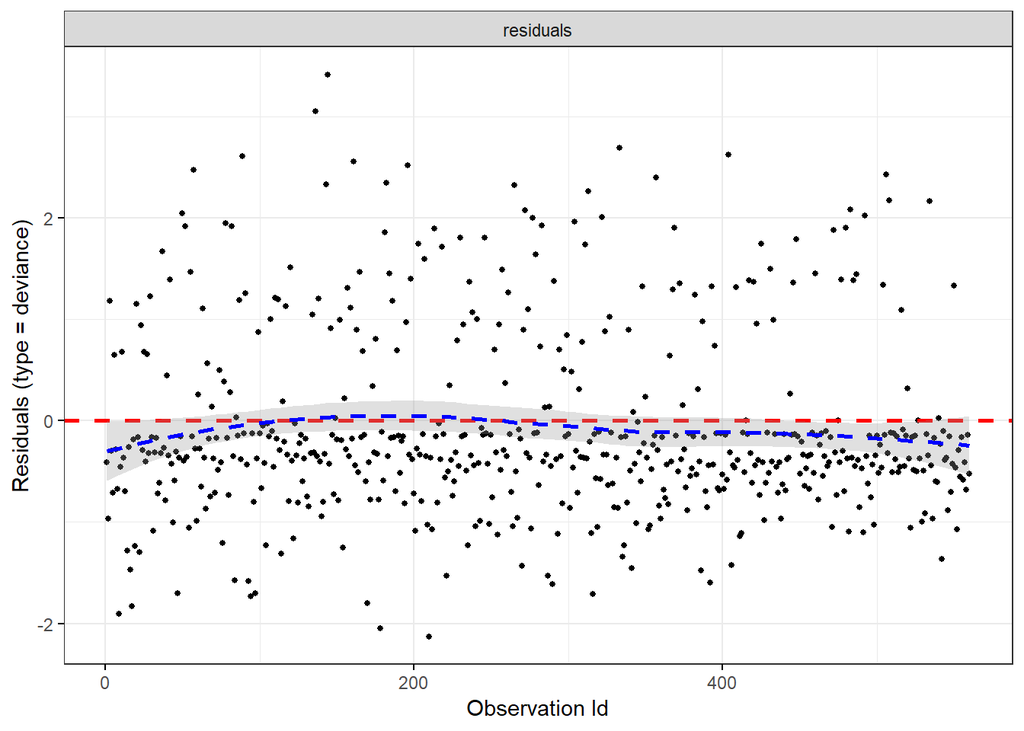

#### Analysis of regression coefficients

To perform one more test (yes, there are still others!), we’ll ask: If you exclude an observation from the data and refit the model, you will get new parameter estimates. How much do the estimates change?

These residuals represent the estimated changes in the regression coefficients upon deleting each observation in turn and then dividing them by their standard errors.

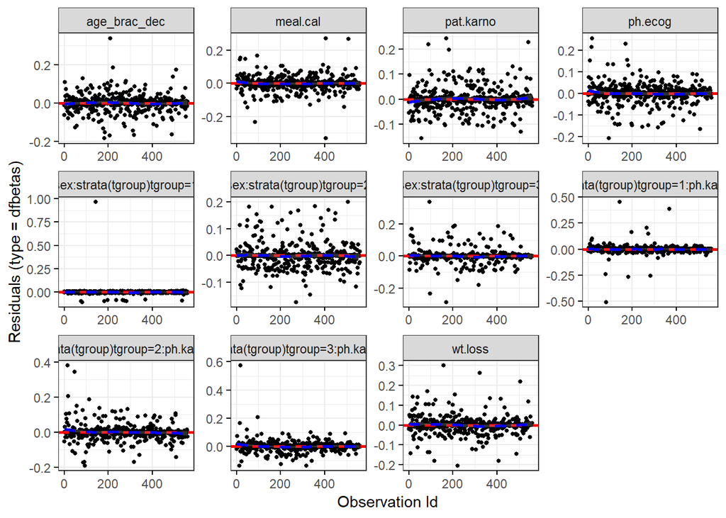